# Weight Lifting Activity Recognition

Karthik Arumugham

11 May 2016

## Executive Summary

Qualitative activity recognition differs from conventional activity recognition in a distinctive way. While the latter is concerned with recognising which activity is performed, the former is concerned with assessing how (well) it is performed. The term `quality` is defined as ‘conformance to specifications’. If the manner of execution of an activity is specified, then the quality can be measured by comparing its execution against this specification. Accelerometers were placed on the belt, arm-band and glove of 6 participants and on the dumbell to classify different exercises and count training repetitions. They performed barbell lifts correctly and incorrectly in 5 different ways.

The goal of this project is to apply machine learning techniques to accurately predict the manner in which the participants did the exercise. This report describes how the model for the project was built, its cross validation, expected out of sample error calculation, and the choices made. It was used successfully to accurately predict all 20 different test cases.

Source: [Weight Lifting Dataset](http://groupware.les.inf.puc-rio.br/har)

## Loading data

```r
if(!file.exists('pml-training.csv')){
    download.file("https://d396qusza40orc.cloudfront.net/predmachlearn/pml-training.csv","pml-training.csv")
}
if(!file.exists('pml-testing.csv')){
    download.file("https://d396qusza40orc.cloudfront.net/predmachlearn/pml-testing.csv","pml-testing.csv")
}
training <- read.csv("pml-training.csv", na.strings = c("NA", "#DIV/0!", ""))
testing <- read.csv("pml-testing.csv", na.strings = c("NA", "#DIV/0!", ""))
```

The dataset has many junk entries such as NA, #DIV/0! and blank cells. This must forced as NA so that it can be cleaned in the next step.

## Cleaning data

```r
train<-training[, apply(training, 2, function(x) !any(is.na(x)))]
test<-testing[, apply(testing, 2, function(x) !any(is.na(x)))]
train <- train[,-c(1:7)]; test <- test[,-c(1:7)]
dim(train); dim(test)
```

```
## [1] 19622    53
```

```
## [1] 20 53
```

```r
library(caret); nearZeroVar(train)
```

Dropping all variables with NA values. Dropping user and time related fields. There are no variables that have one/few unique values. So `53` variables are suitable to fit the model. The `classe` variable is the factor variable with categories A,B,C,D&E that needs to be predicted for the manner in which the exercise was carried out.

## Exploring correlations

```r
library(reshape2);
corMat <- round(cor(train[,-53]),2)
hc <- hclust(as.dist((1-corMat)/2))
corMat <-corMat[hc$order, hc$order]
corMat[lower.tri(corMat)]<- NA; diag(corMat) <- NA
corMat <- melt(corMat, na.rm = TRUE)
```

**Plot 1: Correlation between all variables**: This shows that the variables are mostly uncorrelated. But there are few highly correlated variables (+/- 0.8 threshold) which either must be dropped or must be subjected to a PCA.

```r
subset(corMat, value>=0.8); subset(corMat, value<=-0.8)
```

```
##                  Var1             Var2 value
## 158   gyros_forearm_y  gyros_forearm_z  0.85
## 159  gyros_dumbbell_z  gyros_forearm_z  0.93
## 265      accel_belt_y        roll_belt  0.92
## 317      accel_belt_y total_accel_belt  0.93
## 318         roll_belt total_accel_belt  0.98
## 583       accel_arm_x     magnet_arm_x  0.81
## 795    pitch_dumbbell accel_dumbbell_x  0.81
## 1007     yaw_dumbbell accel_dumbbell_z  0.85
## 1855     magnet_arm_y     magnet_arm_z  0.81
## 1982        roll_belt         yaw_belt  0.82
## 2120     accel_belt_x    magnet_belt_x  0.89
```

```
##                  Var1             Var2 value
## 1511 gyros_dumbbell_z gyros_dumbbell_x -0.98
## 1512  gyros_forearm_z gyros_dumbbell_x -0.91
## 2046       pitch_belt     accel_belt_x -0.97
## 2098       pitch_belt    magnet_belt_x -0.88
## 2413      gyros_arm_x      gyros_arm_y -0.92
## 2449     accel_belt_y     accel_belt_z -0.93
## 2450        roll_belt     accel_belt_z -0.99
## 2451 total_accel_belt     accel_belt_z -0.97
```

## Data Partition

```r
set.seed(12345)
inTrain<-createDataPartition(y=train$classe, p=0.75,list=F)
train<-train[inTrain,]; val<-train[-inTrain,]
dim(train); dim(val)
```

```
## [1] 14718    53
```

```
## [1] 3683   53
```

## Algorithm selection

**Machine Specifications**

- R version 3.2.4 (2016-03-10)
- Platform: x86_64-apple-darwin13.4.0 (64-bit)
- Running under: OS X 10.10.5 (Yosemite)

**Algorithm Performance**

| Algorithm | Package | Method | Time (min) | Accuracy |
| --- | --- | --- | --- | --- |
| Random Forest | caret | rf | 9.230 | 1.0000 |
| Stochastic Gradient Boosting | caret | gbm | 1.540 | 0.9756 |
| eXtreme Gradient Boosting | caret | xgbTree | 0.121 | 1.0000 |
| eXtreme Gradient Boosting | xgboost | xgboost | 0.106 | 1.0000 |

## Cross Validation: eXtreme Gradient Boosting

```r
library(xgboost)
y <- as.numeric(train$classe)
param <- list("objective" = "multi:softmax", eval_metric = "merror",
              num_class = 12, eta = 1, gamma = 0,
              colsample_bytree = 0.85, min_child_weight = 1)
mdepth = 20; folds = 5; iterations = 100
fit_xgb_cv <- xgb.cv(param=param, data=as.matrix(train[,-53]), label=y,
                     nfold=folds, nrounds=iterations, max_depth = mdepth,
                     early.stop.round = 3, maximize = FALSE, verbose=0)
```

```
## Stopping. Best iteration: 25
```

## Model Building: eXtreme Gradient Boosting

```r
iterations = 25; mdepth = 17
fit_xgb = xgboost(param=param, data=as.matrix(train[,-53]), label=y,
                  nrounds=iterations, max_depth = mdepth, verbose=0)
confusionMatrix(predict(fit_xgb, as.matrix(val[,-53])), as.numeric(val$classe))
```

```
## Confusion Matrix and Statistics
##
##           Reference
## Prediction    1    2    3    4    5
##          1 1029    0    0    0    0
##          2    0  717    0    0    0
##          3    0    0  652    0    0
##          4    0    0    0  594    0
##          5    0    0    0    0  691
##
## Overall Statistics
##
##                Accuracy : 1
##                  95% CI : (0.999, 1)
##     No Information Rate : 0.2794
##     P-Value [Acc > NIR] : < 2.2e-16
##
##                   Kappa : 1
##  Mcnemar's Test P-Value : NA
##
## Statistics by Class:
##
##                      Class: 1 Class: 2 Class: 3 Class: 4 Class: 5
## Sensitivity            1.0000   1.0000    1.000   1.0000   1.0000
## Specificity            1.0000   1.0000    1.000   1.0000   1.0000
## Pos Pred Value         1.0000   1.0000    1.000   1.0000   1.0000
## Neg Pred Value         1.0000   1.0000    1.000   1.0000   1.0000
## Prevalence             0.2794   0.1947    0.177   0.1613   0.1876
## Detection Rate         0.2794   0.1947    0.177   0.1613   0.1876
## Detection Prevalence   0.2794   0.1947    0.177   0.1613   0.1876
## Balanced Accuracy      1.0000   1.0000    1.000   1.0000   1.0000
```

## Model Inspection

**Plot 2: Model Complexity**: The upper plot shows the number of leaves per level of deepness. The lower plot shows noramlized weighted cover per leaf (weighted sum of instances). From this information, we can see that the number of leaves is low after level 17. To avoid overfitting, we can restrict the depth of trees at 17.

**Plot 3: Feature Importance**: In xgboost, the importance is decided based on the gain on each node contributed by the variable used for splitting. It is evident that not all variables are necessary for accurate prediction. Besides there are few clusters. So a PCA can reduce the variables and still capture a larger variance. But this is beyond the scope for this project.

## Model scoring

```r
as.character(predict(fit_xgb, as.matrix(test[,-53])))
```

```
##  [1] "2" "1" "2" "1" "1" "5" "4" "2" "1" "1" "2" "3" "2" "1" "5" "5" "1"
## [18] "2" "2" "2"
```

This model successfully scored 100% on all the 20 test cases.

## Conclusion

The 100% accuracy obtained for a dataset with 19k+ observations is a bit suspicious as machine learning algorithms are rarely that accurate. There could be a few potential problems in data gathering. The number of participants might be too low which could induce a bias for similar body types. Or there might be an inherent flaw in factor coding forcing either one of the factors every time due to the highly controlled data collection environment.

## Appendix

**Plot 1: Correlation between all variables**

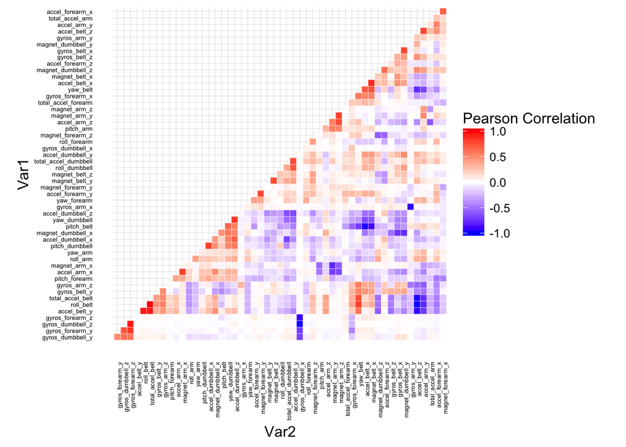

```r
ggplot(corMat, aes(Var2, Var1, fill = value))+
    geom_tile(color = "white")+
    scale_fill_gradient2(low = "blue", high = "red", mid = "white",midpoint = 0,
                         limit = c(-1,1), space = "Lab",name="Pearson Correlation")+
    theme_minimal()+coord_fixed()+theme(axis.text.y = element_text(size = 5))+
    theme(axis.text.x = element_text(angle=90,vjust = 1,size = 5, hjust = 1))
```

**Plot 2: Model Complexity**

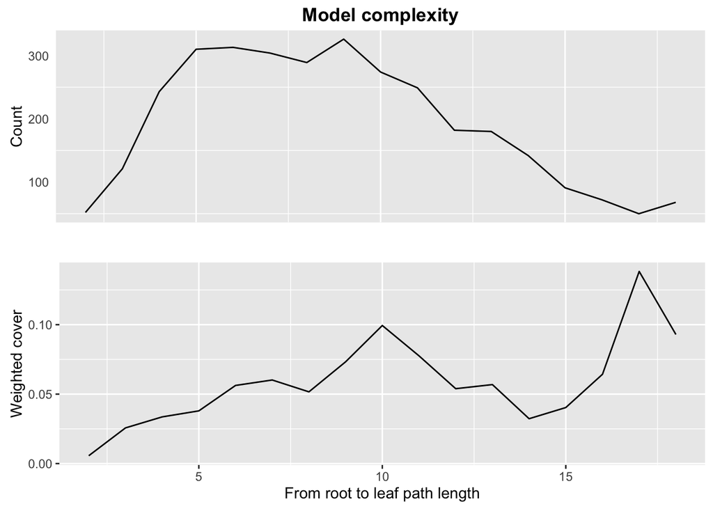

```r
library(igraph)
xgb.plot.deepness(model = fit_xgb)
```

**Plot 3: Feature Importance**

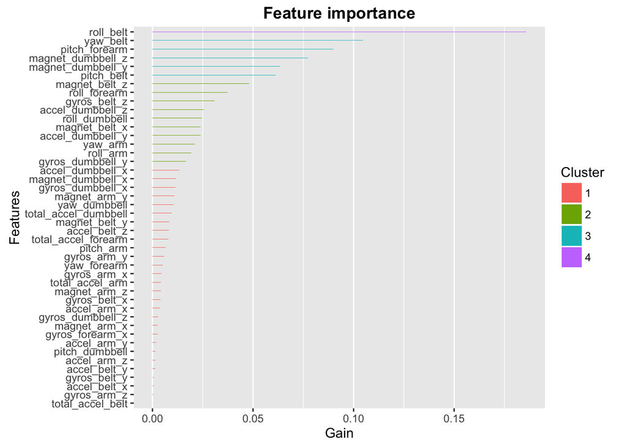

```r
library(Ckmeans.1d.dp)
importance_matrix <- xgb.importance(names(train), model = fit_xgb)
xgb.plot.importance(importance_matrix)
```